# Distribution Free Methods: Permutation Tests

## Optional background reading

Churchill, G. A., and R. W. Doerge. 1994. Empirical threshold values for quantitative trait mapping. Genetics 138:963-971.

## Genetic Mapping

- Over 11,000 linear models, one per position
- How many do we expect to be significant by chance?

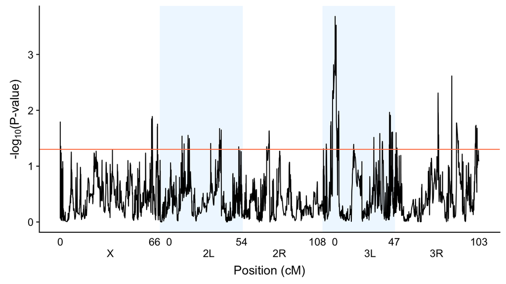

## Genetic Mapping

What is the threshold where we expect to find at least one significant hit by chance alone 5% of the time?

- Find expectation of the random strength of association between genotype and phenotype by shuffling the phenotypes
  - Iterate, perform 11k linear models for each
  - Choose maximum -log<sub>10</sub>P each time

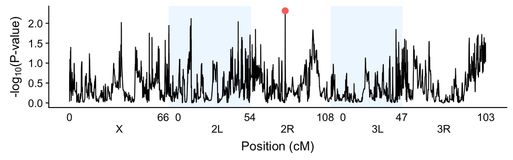

## Distribution of Maxima

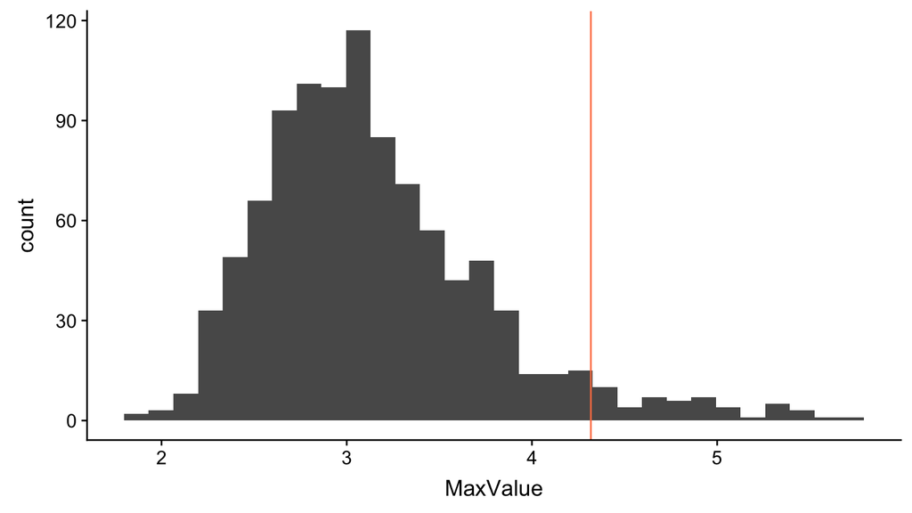

## Genetic Mapping

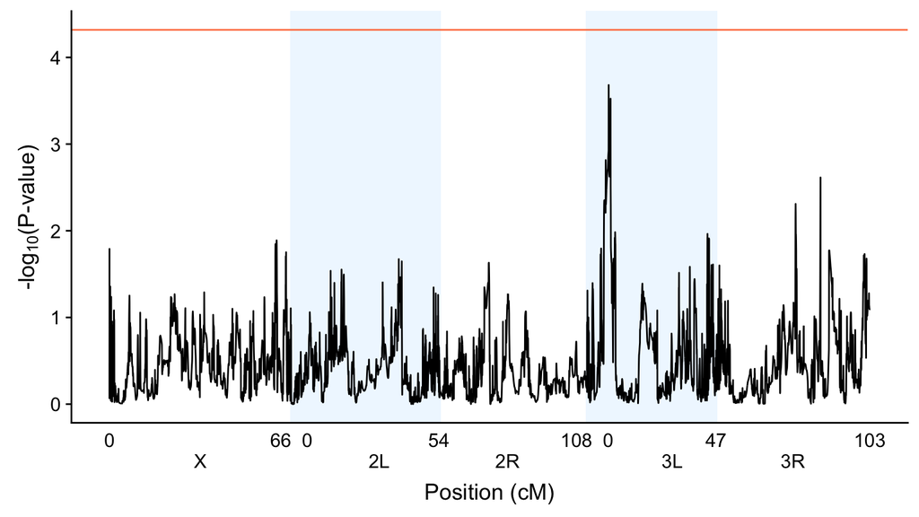

## Cautionary Tale: Don’t assume randomization will always work

- Pooled sequencing of young and old flies: which haplotypes are associated with living a long time?
- Roughly knew the population of possible genomes
- Had the illumina reads from young pool and old pool

## Cautionary Tale: Don’t assume randomization will always work

Sources of Sampling Error

- Choosing 100 females for each pool
- Prepping library & sequencing

## Approach 1: Use known population to estimate expectations from randomly choosing 100 females for each pool

[figure not shown]

## Approach 2: Randomize the illumina read labels (young & old) and recalculate differences in haplotype frequencies

[figure not shown]

## Turning flight in hummingbirds

[figure not shown]

## Turning flight in hummingbirds

[figure not shown]

## Turning flight in hummingbirds

[figure not shown]

## Turning flight in hummingbirds

[figure not shown]

## No Quiz

End of Lectures